# Programming

“10. Sklearn librray”

“Wen-Bin Chuang”

“2024/07/25”

# Today’s Topics

- Sklearn librray
- Machine Learning
- Regression
- Classification

# Introduction

Machine learning is a branch of artificial intelligence that enables computers to learn from data and make predictions or decisions based on that data. Python has become one of the most popular programming languages for machine learning due to its simplicity, flexibility, and powerful libraries.

Within machine learning, there are two basic approaches: **supervised learning** and **unsupervised learning**. The main difference is that one uses labeled data to help predict outcomes, while the other does not.

Scikit-learn, also known as **sklearn**, is an open-source, machine learning and data modeling library for Python. It features various classification, regression and clustering algorithms including support vector machines, random forests, gradient boosting, k-means and DBSCAN, and is designed to interoperate with the Python libraries, NumPy and SciPy.

# **Supervised Machine Learning**

Supervised learning is where you have input variables (x) and an output variable (Y) and you use an algorithm to learn the mapping function from the input to the output.
$$Y=f(X)$$
The goal is to approximate the mapping function so well that when you have new input data (x) that you can predict the output variables (Y) for that data.

It is called supervised learning because the process of an algorithm learning from the training dataset can be thought of as a teacher supervising the learning process.

We know the correct answers, the algorithm iteratively makes predictions on the training data and is corrected by the teacher. Learning stops when the algorithm achieves an acceptable level of performance.

[figure not shown]

## Unsupervised Machine Learning

Unsupervised learning is where you only have input data (X) and no corresponding output variables.

The goal for unsupervised learning is to model the underlying structure or distribution in the data in order to learn more about the data.

These are called unsupervised learning because unlike supervised learning above there is no correct answers and there is no teacher. Algorithms are left to their own devises to discover and present the interesting structure in the data.

# Two problems for Supervised Learning

Supervised learning problems can be further grouped into regression and classification problems.

- **Classification**: A classification problem is when the output variable is a *category*, such as “Sell stock” or “BUY stock” and “Hold stock”. Sometimes these categories are represented by numbers but their value carries no meaning. They are just labels.
- **Regression**: A regression problem is when the output variable is a real number value, such as “House Price” or “Returns”.

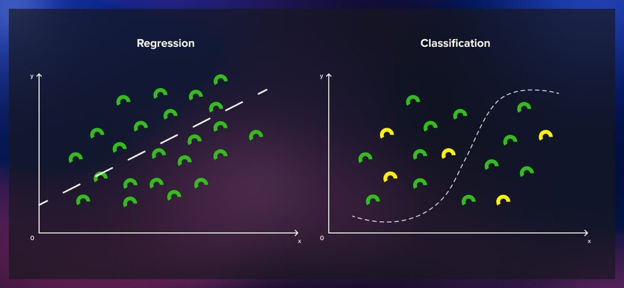

## Two problems for Unsupervised Learning

Unsupervised learning problems can be further grouped into clustering and association problems.

- **Clustering**: A clustering problem is where you want to discover the inherent groupings in the data, such as grouping customers by purchasing behavior.
- **Association**: An association rule learning problem is where you want to discover rules that describe large portions of your data, such as people that buy X also tend to buy Y.

[figure not shown]

# Supervised Learning

## Fundamental for Supervised Learning

In supervised learning, **labeled** data is used to train a model, where each data point is associated with a **corresponding target** or output value.

The model learns from this labeled data to make predictions or classify new, unseen data accurately. Additionally, supervised learning requires the selection of an appropriate algorithm and the evaluation of the model’s performance using metrics such as accuracy or precision. It’s crucial to grasp the two main components:

- input features
- target labels.

**Input Features:** These are the variables or attributes that describe the data. For instance, in a trading strategy, the input features might include the technological index such as MACD, RSI, EMA, BB…etc. The algorithm uses these features to make predictions.

**Target Labels:** Target labels are the values we want the algorithm to predict or classify. In the case of trading detection, it is the classification problem. The target labels would be binary: “Buy” (1) or “Sell” (0). These labels are provided as part of the training data.

## Workflow of Supervised Learning Algorithms

[figure not shown]

- Step 1: **Data Collection**
- Step 2: **Data pre-processing**:
  - missing values, encoding categorical variables, and scaling numerical features
  - feature selection or extraction
- Step 3: **Data Splitting**
- Step 4: **Model Selection**
- Step 5: **Training the Model**
  - **Model Evaluation**
  - **Fine-tuning**

[figure not shown]

## Common algorithms in Supervised Learning

Common algorithms for classification

- **Logistic regression**, **Decision trees**, **Support vector machines (SVM)**, **K-nearest neighbors (KNN)**, **Random forest**, **Neural networks**, **Deep neural networks**, or deep learning, involve multiple hidden layers

Common algorithms for regression

- **Linear regression**, **Lasso regression**, **Support Vector Regression (SVR)**, **Neural networks (for regression)**

# Model Evaluation

There are various metrics for regression problem. The mean absolute error, mean squared error, and root mean squared error are three of the most common metrics.
$$\text{MAE}=\frac{\sum_{i=1}^n |y_i -\hat{y_i}|}{n}$$

$$\text{MSE} = \frac{1}{n} \sum_{i=1}^n (y_i -\hat{y_i})^2$$

$$\text{RMSE}=\sqrt{\frac{1}{n} \sum_{i=1}^n (y_i -\hat{y_i})^2}$$

for classification problem

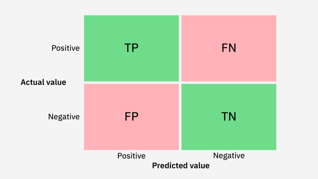

**Confusion Matrix:** A confusion matrix is a table that summarizes the model’s predictions and actual class labels. It provides a more detailed view of a model’s performance, showing true positives, true negatives, false positives, and false negatives.

- **Accuracy:** Accuracy measures the proportion of correctly classified instances out of all instances in the test set
- **Precision:** Precision measures the ratio of true positive predictions to the total positive predictions
- **Recall:** Recall (or sensitivity) measures the ratio of true positives to all actual positives
- **F1-Score:** The F1-score is the harmonic mean of precision and recall.

# Overfitting

Overfitting is a modeling error in statistics that occurs when a function is too closely aligned to a limited set of data points. As a result, the model is useful in reference only to its initial data set, and not to any other data sets.

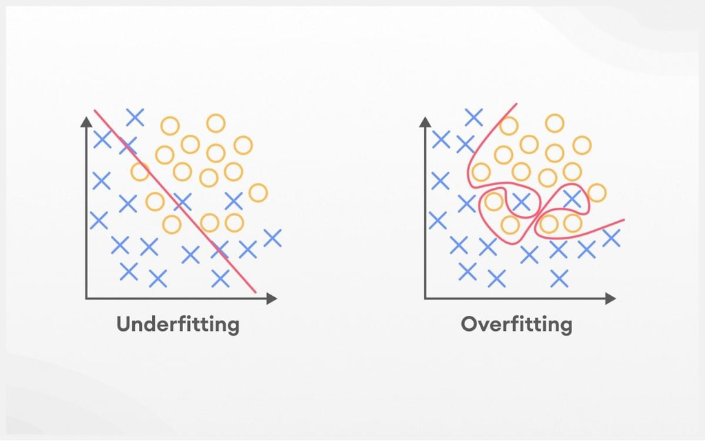